# Analiza jednowymiarowego szeregu czasowego osób odwiedzających Australię w latach 1985-2005

**Instalacja niezbędnych pakietów**

```r
library(forecast)
library(quantmod)
library(tinytex)
library(expsmooth)
library(rmarkdown)
library(rmdformats)
library(datasets)
library(tseries)
library(zoo)
```

### 1. Cel analizy

Celem przeprowadzanej analizy jest zbadanie sezonowości oraz trendu wśród osób odwiedzających Australię w okresie od 1985 do 2005 roku na podstawie danych miesięcznych. Analiza ma na celu identyfikację wzorców i zmian w liczbie krótkoterminowych gości zagranicznych odwiedzających Australię w analizowanych latach.

W szczególności, celem jest ustalenie, czy istnieje sezonowość w liczbie odwiedzających, czyli czy występują regularne wzorce zmian w zależności od pór roku. Ponadto, dążymy do identyfikacji trendu, czyli czy liczba odwiedzających ma tendencję do wzrostu, spadku lub pozostaje stabilna w dłuższym okresie.

Poprzez analizę danych miesięcznych oraz zastosowanie odpowiednich metod statystycznych, badane są sezonowość oraz trend w liczbie odwiedzających Australię. Analiza pozwala również na prognozowanie przyszłych wartości, co może być cenne dla podejmowania decyzji dotyczących zarządzania i planowania związanych z turystyką w Australii.

### 2. Opis i eksploracja zbioru danych

W analizie został wykorzystany jednowymiarowy szereg czasowy “Visitors”, który zawiera informacje dotyczące miesięcznych australijskich krótkoterminowych wizyt zagranicznych (w tys. osób). Zbiór danych obejmuje okres od maja 1985 do kwietnia 2005. Dane te pochodzą z pakietu “expsmooth”. Szereg został załadowany jako zmienna o typie timeseries, dzięki czemu możliwe było przeprowadzenie na nim potrzebnych transformacji czy analiz.

Załadowanie danych:

```r
data(visitors)
```

Sprawdzenie typu danych:

```r
class(visitors)
```

```
## [1] "ts"
```

Wyświetlenie zbioru danych:

```r
print(visitors)
```

```
##        Jan   Feb   Mar   Apr   May   Jun   Jul   Aug   Sep   Oct   Nov   Dec
## 1985                          75.7  75.4  83.1  82.9  77.3 105.7 121.9 150.0
## 1986  98.0 118.0 129.5 110.6  91.7  94.8 109.5 105.1  95.0 130.3 156.7 190.1
## 1987 139.7 147.8 145.2 132.7 120.7 116.5 142.0 140.4 128.0 165.7 183.1 222.8
## 1988 161.3 180.4 185.2 160.5 157.1 163.8 203.3 196.9 179.6 207.3 208.0 245.8
## 1989 168.9 191.1 180.0 160.1 136.6 142.7 175.4 161.4 149.9 174.1 192.7 247.4
## 1990 176.2 192.8 189.1 181.1 149.9 157.3 185.3 178.2 162.7 190.6 198.6 253.1
## 1991 177.4 190.6 189.2 168.0 161.4 172.2 208.3 199.3 197.4 216.0 223.9 266.8
## 1992 196.1 238.2 217.8 203.8 175.2 176.9 219.3 199.1 190.0 229.3 255.0 302.4
## 1993 242.8 245.5 257.9 226.3 213.4 204.6 244.6 239.9 224.0 267.2 285.9 344.0
## 1994 250.5 304.3 307.4 255.1 214.9 230.9 282.5 265.4 254.0 301.6 311.0 384.0
## 1995 303.8 319.1 313.5 294.2 244.8 261.4 329.7 304.9 268.6 320.7 342.9 422.3
## 1996 317.2 392.7 365.6 333.2 261.5 306.9 358.2 329.2 309.2 350.4 375.6 465.2
## 1997 342.9 408.0 390.9 325.9 289.1 308.2 397.4 330.4 330.9 366.5 379.5 448.3
## 1998 346.2 353.6 338.6 341.1 283.4 304.2 372.3 323.7 323.9 354.8 367.9 457.6
## 1999 351.0 398.6 389.0 334.1 298.1 317.1 388.5 355.6 353.1 397.0 416.7 460.8
## 2000 360.8 434.6 411.9 405.6 319.3 347.9 429.0 372.9 403.0 426.5 459.9 559.9
## 2001 416.6 429.2 428.7 405.4 330.2 370.0 446.9 384.6 366.3 378.5 376.2 523.2
## 2002 379.3 437.2 446.5 360.3 329.9 339.4 418.2 371.9 358.6 428.9 437.0 534.0
## 2003 396.6 427.5 392.5 321.5 260.9 308.3 415.5 362.2 385.6 435.3 473.3 566.6
## 2004 420.2 454.8 432.3 402.8 341.3 367.3 472.0 405.8 395.6 449.9 479.9 593.1
## 2005 462.4 501.6 504.7 409.5
```

Podsumowanie statystyk dla zbioru:

```r
summary(visitors)
```

```
##    Min. 1st Qu.  Median    Mean 3rd Qu.    Max.
##    75.4   189.2   303.1   288.2   378.7   593.1
```

Na podstawie podsumowania statystycznego otrzymanego dla zbioru danych “Visitors”, można przedstawić następujące informacje:

- Najmniejsza wartość w zbiorze wynosi 75.4 tys.

- 25% wartości w zbiorze jest mniejszych lub równe 189.2 tys.

- Mediana zbioru wynosi 303.1 tys.

- Średnia wartość w zbiorze wynosi 288.2 tys.

- 75% wartości w zbiorze jest mniejszych lub równe 378.7 tys.

- Największa wartość w zbiorze wynosi 593.1 tys.

W kolejnym kroku przeprowadzono dekompozycję w celu sprawdzenia obecności trendu i sezonowości.

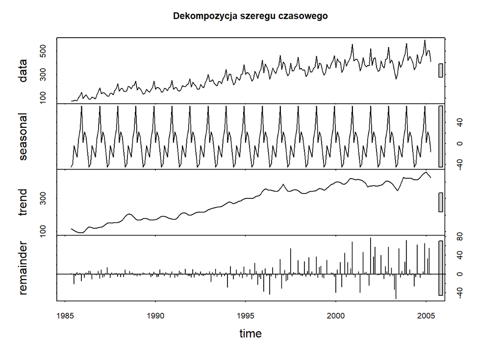

```r
decomp <- stl(visitors, s.window = "periodic", t.window = 7, robust = TRUE)
plot(decomp, main = "Dekompozycja szeregu czasowego")
```

W obrębie analizowanego szeregu wartości są zmienne w zależności od miesiąca, a niezmienne w przekroju lat, co wskazuje na jego sezonowość. Trend ma natomiast tendencję wzrostową.

### 3. Prezentacja graficzna zbioru danych

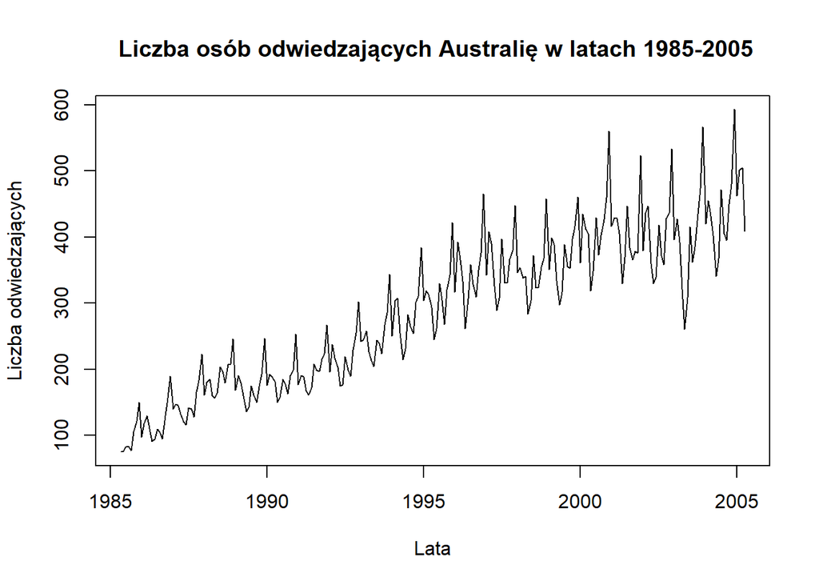

```r
plot(visitors, ylab="Liczba odwiedzających", xlab="Lata", main=" Liczba osób odwiedzających Australię w latach 1985-2005")
```

W analizie danych dotyczących liczby krótkoterminowych gości zagranicznych odwiedzających Australię w okresie od maja 1985 roku do kwietnia 2005 roku, zauważono wyraźny wzrost trendu. Wykres prezentujący te dane ukazuje skierowaną w górę linię, co sugeruje systematyczny wzrost liczby odwiedzających w miarę upływu czasu.

Wzrost linii wykresu odzwierciedla dynamiczny rozwój sektora turystycznego w Australii i zwiększone zainteresowanie krajem jako popularnym celem zarówno dla turystów, jak i osób podróżujących w celach biznesowych.

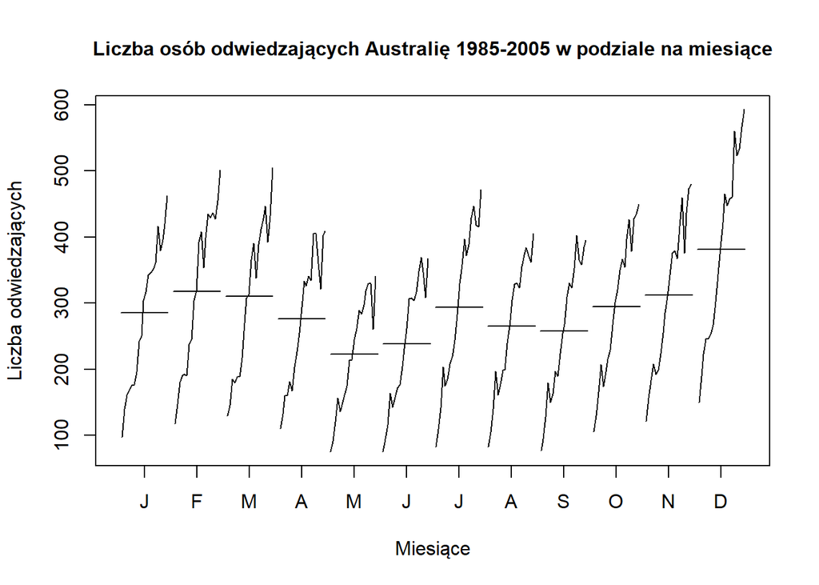

```r
monthplot(visitors, ylab = "Liczba odwiedzających", xlab = "Miesiące", main = "Liczba osób odwiedzających Australię 1985-2005 w podziale na miesiące", cex.main = 0.99)
```

Na wykresie sezonowym dla danych dotyczących gości zagranicznych w Australii możemy zauważyć wyraźne wzorce sezonowe. Istnieje regularna fluktuacja w liczbie gości zagranicznych w poszczególnych miesiącach. Widać, że liczba gości jest zwykle najwyższa w okresie zimowym (w szczególności grudzień), a najniższa w okresie wiosenno-letnim (np. maj, czerwiec).

### 4. Dobór metody analizy odpowiadającej celowi badania

Z uwagi na cel analizy, jakim jest identyfikacja sezonowości oraz trendu wśród osób odwiedzających Australię w latach 1985-2005 na podstawie danych miesięcznych, zdecydowano się na zastosowanie dwóch modeli: modelu wygładzania wykładniczego oraz modelu ARIMA.

#### **4.1 Metody wygładzania wykładniczego**

Metody wygładzania wykładniczego są szeroko stosowane w analizie szeregów czasowych do przewidywania przyszłych wartości i wygładzania fluktuacji danych. Ich głównym celem jest redukcja szumów i nieregularności w szeregach czasowych w celu uchwycenia głównych trendów i wzorców.

Wśród różnych technik wygładzania wykładniczego, wyróżnia się metodę **Holta-Wintersa,** gdyż uwzględnia zarówno trend, jak i sezonowość w analizie szeregów czasowych. Jest więc rozszerzeniem modelu liniowego Holta, który nie uwzględniał sezonowości.

Metoda ta jest szczególnie efektywna w przypadku szeregów czasowych, które wykazują długoterminowy trend rozwojowy oraz powtarzające się wzorce sezonowe.

Główną zaletą metody Holta-Wintersa jest jej zdolność do dokładnego prognozowania przyszłych wartości szeregów czasowych, biorąc pod uwagę zarówno zmiany trendu, jak i sezonowe fluktuacje. W ramach tej metody stosuje się trzy składniki: **poziom, trend i składową sezonową.** Dzięki wygładzaniu tych składników możliwe jest uwzględnienie wpływu zarówno długoterminowych zmian, jak i powtarzających się sezonowych wzorców.

W zależności od rodzaju sezonowości, model Holta-Wintersa przyjmuje dwie postacie – addytywną i multiplikatywną.

Model multiplikatywny w odróżnieniu od modelu addytywnego, w którym składniki trendu i sezonowości są dodawane do poziomu bazowego, model multiplikatywny wykorzystuje iloczyn tych składników.

W przypadku danych dotyczących miesięcznej liczby australijskich krótkoterminowych gości zagranicznych (maj 1985-kwiecień 2005), wybrano **model** **multiplikatywny** ze względu na obserwowaną zależność między sezonowymi zmianami a trendem. W tych danych istnieje tendencja wzrostowa zarówno w liczbie gości zagranicznych, jak i w sezonowych zmianach. Wybór modelu multiplikatywnego pozwala uwzględnić fakt, że wzrost liczby gości zagranicznych i sezonowe zmiany są ze sobą powiązane w sposób proporcjonalny. Co więcej model multiplikatywny pozwala na dokładniejsze odzwierciedlenie wzrostu liczby gości zagranicznych, ponieważ zmiany w liczbie gości są skalowane przez sezonowe fluktuacje. W efekcie, prognozy oparte na tym modelu będą bardziej precyzyjne, a analiza trendów będzie bardziej wiarygodna.

Pomimo starannego doboru modelu multiplikatywnego istnieje pewne ryzyko związane z tym wyborem. Aby zminimalizować to ryzyko i ocenić trafność wybranego modelu, istnieje **alternatywna metoda**, jaką jest **ETS** (Error, Trend, Seasonality) - metoda automatycznego wyboru optymalnego algorytmu.

**Metoda ETS** jest jednym z popularnych podejść do modelowania szeregów czasowych i uwzględnia trzy główne składniki: błędy, trendy i sezonowość. Jest elastyczna, ponieważ automatycznie dopasowuje różne kombinacje tych składników w celu znalezienia optymalnego modelu dla danego szeregu czasowego.  
Zastosowanie metody ETS umożliwia porównanie różnych modeli i ocenę ich trafności w kontekście analizowanego szeregu czasowego. Metoda ta przeprowadza automatyczne testy, oceniając jakość dopasowania modeli, aby wybrać ten, który najlepiej pasuje do danych. Daje to większą pewność co do trafności wyboru modelu, eliminując w pewnym stopniu ryzyko wynikające z subiektywnego podejścia.

Warto podkreślić, że zastosowanie metody ETS jako **alternatywy** dla modelu multiplikatywnego ma na celu zwiększenie pewności prognozowania szeregów czasowych. Wybór optymalnego modelu za pomocą tej metody może prowadzić do lepszych wyników prognozowania, uwzględniając różne składniki i ich kombinacje w danych.

Na zakończenie tej części analizy, wyniki uzyskane za pomocą modelu multiplikatywnego i metody ETS zostaną podsumowane. Obie metody dostarczą prognozy przyszłych wartości szeregu czasowego, uwzględniając różne składniki i ich kombinacje.

Porównanie wyników uzyskanych z obu metod pozwoli ocenić, która z nich lepiej odzwierciedlała analizowany szereg czasowy i zapewniała trafniejsze prognozy. Ostateczna ocena zostanie oparta na różnych wskaźnikach oceny modeli, takich jak błąd średniokwadratowy (RMSE), średni procentowy błąd (MAPE), czy błąd średni absolutny (MAE).

Dzięki podsumowaniu wyników za pomocą obu metod, analiza szeregu czasowego będzie bardziej kompletna i pozwoli na dokładniejsze zrozumienie jego charakterystyki i przyszłego rozwoju.

#### **4.2 ARIMA**

**ARIMA** (AutoRegressive Integrated Moving Average) jest modelem czasowym używanym do prognozowania szeregów czasowych. Składa się z trzech składowych: AR (AutoRegressive), I (Integrated) i MA (Moving Average). Każda z tych składowych ma określone znaczenie:

- **Składowa AR** (AutoRegressive) odnosi się do regresji modelu na jego poprzednie wartości. Oznacza to, że wartość w danym punkcie czasowym jest liniową kombinacją wartości z wcześniejszych punktów czasowych.
- **Składowa I** (Integrated) odnosi się do różnicy między wartościami w kolejnych okresach czasowych. Celem tej składowej jest transformacja pierwotnego szeregu czasowego na szereg stacjonarny, co ułatwia modelowanie.
- **Składowa MA** (Moving Average) odnosi się do średniej ruchomej modelu, gdzie wartość w danym punkcie czasowym jest liniową kombinacją błędów modelu w poprzednich punktach czasowych.

Model ten jest skuteczny w wykrywaniu wzorców, trendów i sezonowości w danych, co pozwala na prognozowanie przyszłych wartości. W przypadku danych dotyczących osób odwiedzających Australię, ARIMA może pomóc w prognozowaniu liczby odwiedzających w przyszłych okresach na podstawie wcześniejszych obserwacji.

**AIC** (Akaike’s Information Criterion), **AICc** (corrected AIC) i **BIC** (Bayesian Information Criterion) to popularne metryki używane do oceny jakości dopasowania modeli statystycznych i do wyboru najlepszego modelu spośród zestawu alternatywnych modeli. Wszystkie trzy metryki mają na celu zbalansowanie dokładności dopasowania modelu z jego złożonością, aby wybrać model, który dobrze uogólnia dane i minimalizuje ryzyko przeuczenia. AIC jest miarą względnej jakości modelu statystycznego. Oparta jest na funkcji prawdopodobieństwa modelu i uwzględnia liczbę parametrów modelu. Im niższa wartość AIC, tym lepiej model uogólnia dane. AIC preferuje modele, które są zarówno dobrze dopasowane do danych, jak i mają małą liczbę parametrów. Natomiast AICc jest poprawioną wersją AIC, zaproponowaną przez Hirotugu Akaike. AICc uwzględnia korektę na podstawie wielkości próbki i liczby parametrów w modelu. Jest szczególnie przydatne w przypadku małych próbek, gdzie AIC może faworyzować zbyt skomplikowane modele. AICc ma tendencję do wybierania prostszych modeli niż AIC dla małych próbek. Z kolei BIC, znany również jako kryterium informacyjne Bayesa, jest oparty na podejściu bayesowskim do oceny modeli. BIC uwzględnia zarówno dopasowanie modelu do danych, jak i złożoność modelu. BIC kara bardziej skomplikowane modele niż AIC, co sprzyja wyborowi modeli o mniejszej złożoności. W BIC kara za zbyt dużą złożoność jest większa niż w AIC. W przypadku oceny modeli ARIMA dla zbioru “Visitors” zastosowano te trzy metryki i wybrano model o najniższej wartości AIC.

Reszty modelu odnoszą się do różnicy między prognozowanymi wartościami a rzeczywistymi wartościami w szeregu czasowym. Analiza reszt modelu jest istotna, ponieważ pozwala ocenić, czy model jest w stanie uchwycić strukturę danych. Analiza reszt może obejmować sprawdzenie ich losowości, stacjonarności, niezależności i normalności. Jeśli reszty mają jakieś wzorce lub struktury, może to wskazywać na niewystarczającą jakość dopasowania modelu.

**ACF (Autocorrelation Function)** to funkcja autokorelacji, która mierzy korelację między wartościami w szeregu czasowym a ich opóźnieniami. Jeśli funkcja ACF dla reszt wykazuje znaczące wartości niezerowe na różnych opóźnieniach, może to sugerować, że model ARIMA nie uwzględnił całkowicie struktury danych. W takim przypadku możliwe jest, że dalsze dopasowanie modelu lub uwzględnienie dodatkowych składowych może być konieczne. Analiza funkcji ACF dla reszt modelu jest ważnym krokiem w ocenie jakości dopasowania modelu i identyfikacji możliwych obszarów do dalszej poprawy.

**Test Boxa-Ljunga** służy do sprawdzenia istnienia autokorelacji w resztach szeregu czasowego. Wykorzystuje on autokorelację cząstkową (PACF) reszt do oceny statystycznej. Hipotezy testu Boxa-Ljunga są następujące:

- Hipoteza zerowa (H0): Reszty nie wykazują autokorelacji (są niezależne).
- Hipoteza alternatywna (H1): Reszty wykazują autokorelację (nie są niezależne).

W procedurze testu oblicza się statystykę testową, która porównuje sumę kwadratów autokorelacji cząstkowych reszt z rozkładem chi-kwadrat. Wartość p-wartości porównuje się z ustalonym poziomem istotności (np. 0,05) i jeśli jest mniejsza, odrzuca się hipotezę zerową, stwierdzając, że reszty mają autokorelację. Analiza autokorelacji reszt ma na celu identyfikację ukrytych wzorców w danych. Jeśli reszty wykazują istotną autokorelację, może to wskazywać na niedopasowanie modelu lub brak uwzględnienia ważnych czynników, które wpływają na szereg czasowy. W takim przypadku konieczne może być dostosowanie modelu lub dodanie dodatkowych czynników w celu uwzględnienia tych zależności.

Kolejnym przeprowadzonym testem był **test Shapiro-Wilka**, który jest wykorzystywany do sprawdzenia, czy dany zbiór danych posiada rozkład normalny. Test ten oparty jest na obliczeniu statystyki testowej opartej na porównaniu obserwowanej dystrybuanty z dystrybuantą teoretyczną rozkładu normalnego. Hipoteza zerowa mówi o tym, że badane dane pochodzą z rozkładu normalnego, a hipoteza alternatywna jest jej zaprzeczeniem. W przypadku testu Shapiro-Wilka, wartość p-value porównuje się z ustalonym poziomem istotności (np. 0,05). Jeśli wartość p jest mniejsza od ustalonego poziomu istotności, odrzuca się hipotezę zerową, stwierdzając, że badane dane nie pochodzą z rozkładu normalnego.

### **5. Analiza-interpretacja wyników**

#### **5.1 Metody wygładzania wykładniczego**

Jak wspomniano wyżej, w celu uzyskania lepszych wyników prognozowania zastosowano zarówno manualne, jak i automatyczne metody. Pierwszym etapem było wykorzystanie ręcznego podejścia, a konkretnie **metody Holta-Wintersa** z modelem multiplikatywnym.

```r
visitors.hw.multi <-hw(visitors, h=24, seasonal="multiplicative")
```

**Wykres**

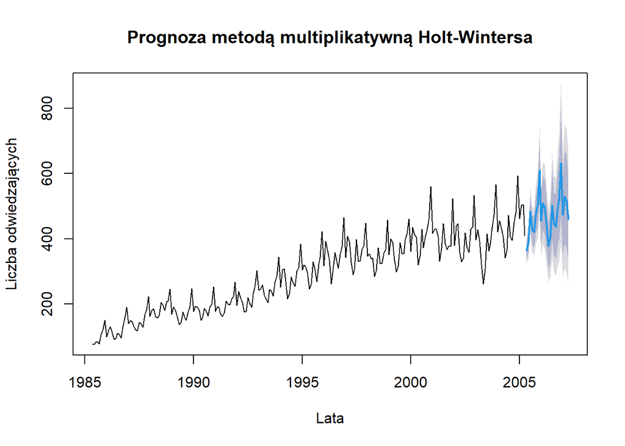

```r
plot(visitors.hw.multi, ylab="Liczba odwiedzających", xlab="Lata",main="Prognoza metodą multiplikatywną Holt-Wintersa")
```

Na podstawie prognozy z zastosowaniem modelu Holta-Wintersa w wariancie multiplikatywnym dla danych dotyczących miesięcznej liczby australijskich krótkoterminowych gości zagranicznych (maj 1985-kwiecień 2005), wynika, że wartości te będą rosły w przyszłości. Prognoza uwzględnia zarówno trend wzrostowy, jak i sezonowe fluktuacje, które wskazują na dalszy rozwój liczby gości zagranicznych w kolejnych okresach. Przez kolejne 24 miesiące przewidywane jest wzrost liczby gości zagranicznych, co sugeruje, że sektor turystyczny Australii może oczekiwać wzrostu odwiedzających w najbliższej przyszłości.

Stworzono także **wykres dopasowania** multiplikatywnego algorytmu Holta-Wintersa do oryginalnego szeregu czasowego liczby odwiedzających. Oś y reprezentuje liczbę odwiedzających, a oś x oznacza lata. Wykres pomaga wizualnie ocenić, jak dobrze model multiplikatywny Holta-Wintersa dopasowuje się do danych. Porównanie linii dopasowanych z oryginalnym szeregiem czasowym pozwala ocenić trafność i skuteczność modelu w odwzorowaniu rzeczywistości.

**Wykres dopasowania**

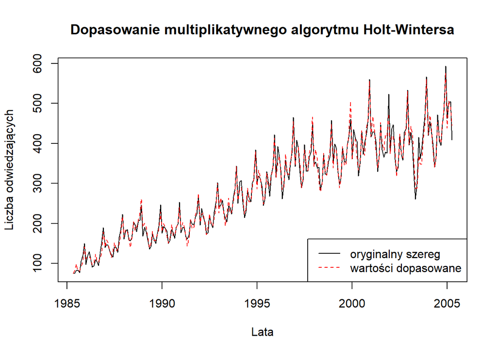

```r
plot(visitors, ylab="Liczba odwiedzających", xlab="Lata",
     main="Dopasowanie multiplikatywnego algorytmu Holt-Wintersa")
lines(fitted(visitors.hw.multi), lty=2, col="red")
legend("bottomright",
       legend=c("oryginalny szereg", "wartości dopasowane"),
       col=c("black", "red"), lty=c(1,2))
```

Obserwując wykres, można zauważyć, że te wartości dopasowane pokrywają się z rzeczywistymi wartościami, reprezentowanymi przez czarną linię ciągłą. To oznacza, że model Holt-Wintersa w wariancie multiplikatywnym dobrze odzwierciedla trendy i wzorce w danych, umożliwiając trafne prognozowanie zachowań przyszłych wartości. Taka zgodność między wartościami dopasowanymi a rzeczywistymi wskazuje na skuteczność modelu w analizie i prognozowaniu danych dotyczących miesięcznej liczby australijskich krótkoterminowych gości zagranicznych.

**Podsumowanie prognozy**

```r
summary(visitors.hw.multi)
```

```
##
## Forecast method: Holt-Winters' multiplicative method
##
## Model Information:
## Holt-Winters' multiplicative method
##
## Call:
##  hw(y = visitors, h = 24, seasonal = "multiplicative")
##
##   Smoothing parameters:
##     alpha = 0.5653
##     beta  = 0.0215
##     gamma = 5e-04
##
##   Initial states:
##     l = 91.7613
##     b = 2.4333
##     s = 0.935 1.0545 1.0841 0.9724 1.3037 1.0824
##            1.0258 0.9102 0.9304 1.0521 0.8518 0.7976
##
##   sigma:  0.0565
##
##      AIC     AICc      BIC
## 2628.219 2630.976 2687.390
##
## Error measures:
##                       ME    RMSE      MAE        MPE     MAPE      MASE
## Training set -0.09495709 14.6622 10.97229 -0.3070136 4.188878 0.4051965
##                    ACF1
## Training set 0.07998858
##
## Forecasts:
##          Point Forecast    Lo 80    Hi 80    Lo 95    Hi 95
## May 2005       363.6434 337.2901 389.9967 323.3395 403.9474
## Jun 2005       389.5974 356.8764 422.3184 339.5550 439.6399
## Jul 2005       482.7709 437.0247 528.5172 412.8081 552.7338
## Aug 2005       428.5001 383.4951 473.5050 359.6709 497.3293
## Sep 2005       420.4548 372.1236 468.7860 346.5386 494.3710
## Oct 2005       475.5963 416.3290 534.8636 384.9547 566.2379
## Nov 2005       503.4598 435.9471 570.9725 400.2080 606.7116
## Dec 2005       608.3779 521.1122 695.6436 474.9165 741.8393
## Jan 2006       455.1525 385.6597 524.6452 348.8725 561.4324
## Feb 2006       509.0590 426.6702 591.4478 383.0562 635.0618
## Mar 2006       496.8101 411.8771 581.7431 366.9162 626.7039
## Apr 2006       441.9586 362.3923 521.5249 320.2724 563.6448
## May 2006       378.2099 306.6932 449.7266 268.8345 487.5852
## Jun 2006       405.1516 324.8788 485.4244 282.3849 527.9183
## Jul 2006       501.9810 397.9885 605.9736 342.9382 661.0239
## Aug 2006       445.4943 349.1776 541.8110 298.1906 592.7980
## Sep 2006       437.0751 338.6243 535.5258 286.5076 587.6425
## Oct 2006       494.3345 378.5064 610.1626 317.1908 671.4783
## Nov 2006       523.2309 395.8806 650.5813 328.4653 717.9965
## Dec 2006       632.1913 472.5654 791.8172 388.0646 876.3180
## Jan 2007       472.9103 349.1848 596.6358 283.6884 662.1322
## Feb 2007       528.8557 385.6501 672.0612 309.8416 747.8697
## Mar 2007       516.0680 371.5831 660.5529 295.0974 737.0386
## Apr 2007       459.0351 326.2850 591.7853 256.0113 662.0590
```

Następnie dokonano podsumowania wyników prognozy:

**Parametry wygładzania:**

- współczynnik wygładzania poziomu: alpha (α) = 0.5653,
- współczynnik wygładzania trendu: beta (β) = 0.0215,
- współczynnik wygładzania składowej sezonowej gamma (γ) = 5e-04 (czyli 0.0005).

Im wyższe wartości tych współczynników, tym większy wpływ mają najnowsze obserwacje na prognozy dotyczące trendu.

**Stan początkowy:**

- początkowa wartość poziomu trendu - 91.7613,
- początkowa wartość współczynnika nachylenia trendu - 2.4333,
- wartości sezonowe dla 12 miesięcy (od stycznia do grudnia).

Sigma (σ), czyli odchylenie standardowe reszt modelu (błędy) wynosi 0.0565

Drugą częścią wygładzania wykładniczego w tej analizie był jak wspomniano wybór optymalnego algorytmu za pomocą metody ETS (Error, Trend, Seasonality), która uwzględnia błędy, trendy, sezonowość w danych i automatycznie dopasowuje różne kombinacje tych składników, aby znaleźć optymalny model dla danego szeregu czasowego.

```r
visitors.ets.auto<-ets(visitors, opt.crit="mse", ic="aicc")
visitors.ets.auto
```

```
## ETS(M,A,M)
##
## Call:
##  ets(y = visitors, opt.crit = "mse", ic = "aicc")
##
##   Smoothing parameters:
##     alpha = 0.5653
##     beta  = 0.0215
##     gamma = 5e-04
##
##   Initial states:
##     l = 91.7613
##     b = 2.4333
##     s = 0.935 1.0545 1.0841 0.9724 1.3037 1.0824
##            1.0258 0.9102 0.9304 1.0521 0.8518 0.7976
##
##   sigma:  0.0565
##
##      AIC     AICc      BIC
## 2628.219 2630.976 2687.390
```

```r
visitors.ets.auto.prognoza <- forecast(visitors.ets.auto, h=24)
```

**Parametry wygładzania:**

- współczynnik wygładzania poziomu: alpha (α) = 0.5653,
- współczynnik wygładzania trendu: beta (β) = 0.0215,
- współczynnik wygładzania składowej sezonowej gamma (γ): Wartość wynosi 5e-04 (czyli 0.0005).

Im wyższe wartości tych współczynników, tym większy wpływ mają najnowsze obserwacje na prognozy dotyczące trendu.

**Stan początkowy:**

- początkowa wartość poziomu trendu - 91.7613,
- początkowa wartość współczynnika nachylenia trendu - 2.4333,
- wartości sezonowe dla 12 miesięcy (od stycznia do grudnia).

Sigma (σ), czyli odchylenie standardowe reszt modelu (błędy) w tym przypadku wynosi 0.0565.

**Wykres**

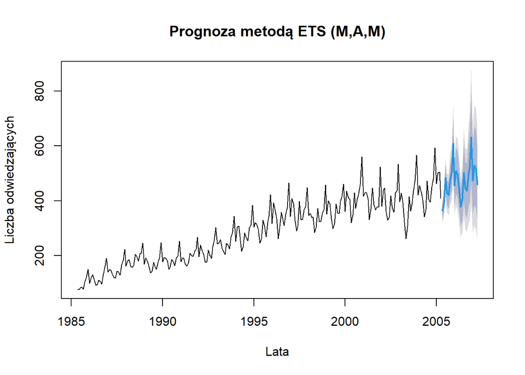

```r
plot(visitors.ets.auto.prognoza, ylab="Liczba odwiedzających", xlab="Lata",main="Prognoza metodą ETS (M,A,M)")
```

Na podstawie prognozy z zastosowaniem modelu ETS (M, A, M) można zauważyć, że wartości szeregu czasowego będą osiągały wyższe wyniki w przyszłości. Model ETS (M, A, M) uwzględnia składniki błędów (M - Multiplicative), trendu (A - Additive) i sezonowości (M - Multiplicative) w danych. Prognoza generowana przez ten model wskazuje na tendencję wzrostową, gdzie wartości szeregu czasowego będą rosły w nadchodzących okresach.

Analizując wyniki prognoz za pomocą metody Holt-Wintersa i ETS (M, A, M), można zauważyć, że oba modele wygenerowały identyczne parametry oraz prognozy. Oznacza to, że oba podejścia do modelowania szeregów czasowych dokładnie przewidziały przyszłe wartości.

Wybór początkowego modelu, czyli modelu Holt-Wintersa, okazał się trafny, ponieważ jego prognozy były zgodne z prognozami uzyskanymi za pomocą metody ETS (M, A, M). To sugeruje, że model Holt-Wintersa dobrze odzwierciedlał charakterystykę analizowanego szeregu czasowego, uwzględniając zarówno trend, jak i sezonowość.

#### 5.2 ARIMA

Analizę ARIMA rozpoczęto od wybrania metryki oceniającej jakość dopasowania modelu do danych (AIC, AICc i BIC) przy użyciu funkcji auto.arima().

```r
optymalny.arima.AIC <- auto.arima(visitors, ic="aic")
optymalny.arima.AIC
```

```
## Series: visitors
## ARIMA(1,0,1)(0,1,2)[12] with drift
##
## Coefficients:
##          ar1      ma1     sma1    sma2   drift
##       0.8968  -0.3187  -0.7110  0.1461  1.4820
## s.e.  0.0379   0.0804   0.0753  0.0723  0.2667
##
## sigma^2 = 279.9:  log likelihood = -966.83
## AIC=1945.66   AICc=1946.04   BIC=1966.24
```

```r
optymalny.arima.AICc <- auto.arima(visitors, ic="aicc")
optymalny.arima.AICc
```

```
## Series: visitors
## ARIMA(1,0,1)(0,1,2)[12] with drift
##
## Coefficients:
##          ar1      ma1     sma1    sma2   drift
##       0.8968  -0.3187  -0.7110  0.1461  1.4820
## s.e.  0.0379   0.0804   0.0753  0.0723  0.2667
##
## sigma^2 = 279.9:  log likelihood = -966.83
## AIC=1945.66   AICc=1946.04   BIC=1966.24
```

```r
optymalny.arima.BIC <- auto.arima(visitors, ic="bic")
optymalny.arima.BIC
```

```
## Series: visitors
## ARIMA(1,0,1)(0,1,1)[12] with drift
##
## Coefficients:
##          ar1      ma1     sma1   drift
##       0.8771  -0.3069  -0.5970  1.4794
## s.e.  0.0414   0.0833   0.0465  0.2208
##
## sigma^2 = 284.5:  log likelihood = -968.68
## AIC=1947.36   AICc=1947.63   BIC=1964.51
```

**Wyliczenie reszt modelu**

Kolejnym etapem były wyliczenie, wizualizacja i analiza reszt modelu ARIMA.

```r
optymalny.arima.AIC.reszty <-optymalny.arima.AIC$resid
```

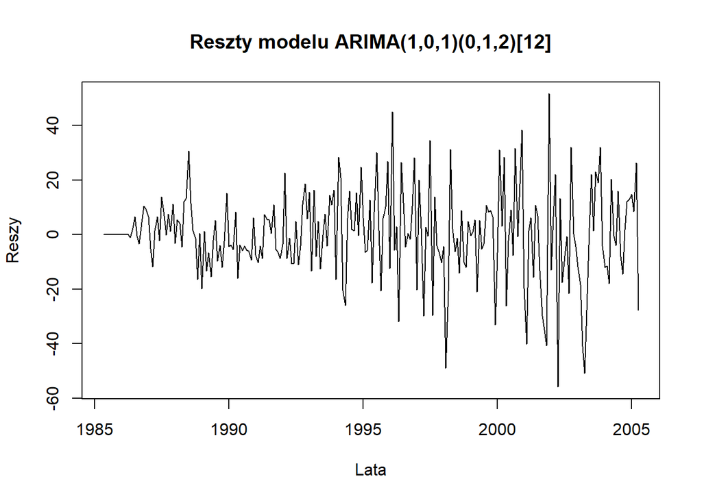

```r
plot(optymalny.arima.AIC.reszty, ylab="Reszy", xlab="Lata",main="Reszty modelu ARIMA(1,0,1)(0,1,2)[12]")
```

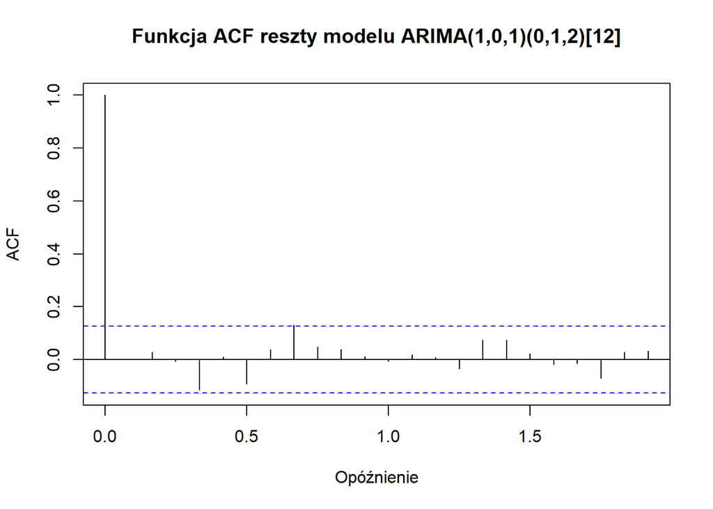

```r
acf(optymalny.arima.AIC.reszty,xlab="Opóźnienie", main="Funkcja ACF reszty modelu ARIMA(1,0,1)(0,1,2)[12]")
```

Można zauważyć, że wartości mieszczą się w przedziale ufności, co oznacza, że można podejrzewać, że nie występuje autokorelacja reszt w analizowanym modelu. Jednak zdecydowano się zastosować dodatkowo **test statystyczny Ljunga-Boxa,** by zweryfikować przypuszczenia.

```r
Box.test(optymalny.arima.AIC.reszty, lag=24, type="Ljung-Box")
```

```
##
##  Box-Ljung test
##
## data:  optymalny.arima.AIC.reszty
## X-squared = 19.26, df = 24, p-value = 0.738
```

W przypadku wyników, otrzymany p-value wynosi 0.738. Jest to wysoka wartość, co sugeruje, że nie ma wystarczających dowodów, aby odrzucić hipotezę zerową o niezależności reszt. To oznacza, że nie ma istotnych dowodów na występowanie autokorelacji w resztach modelu. Przypuszczenia potwierdziła również funkcja tsdiag() - reszty oscylują wokół zera i nie wykazują wzorca czy struktury.

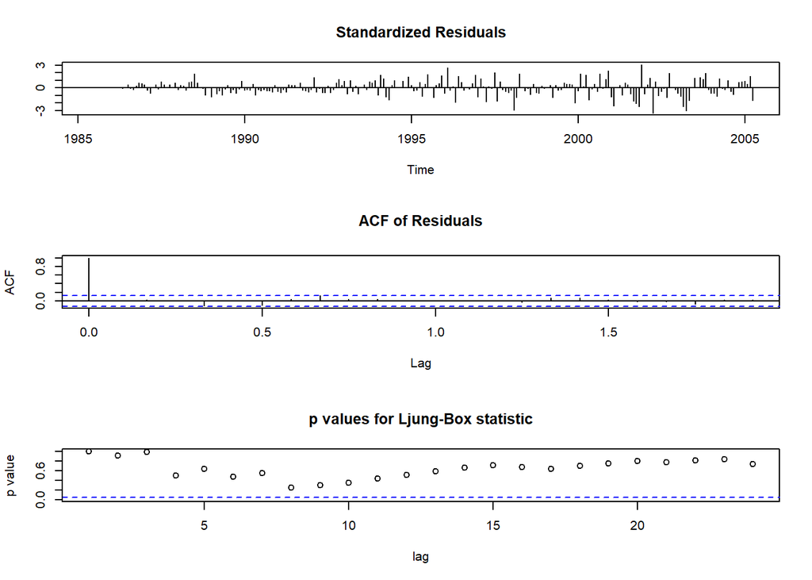

```r
tsdiag(optymalny.arima.AIC, gof.lag=24, main="Diagnostyka reszt modelu")
```

W ramach analizy reszt przeprowadzono także badanie normalności ich rozkładu. W tym celu wykreślono histogram reszt modelu oraz wykres kwantyl-kwantyl.

**Histogram reszt**

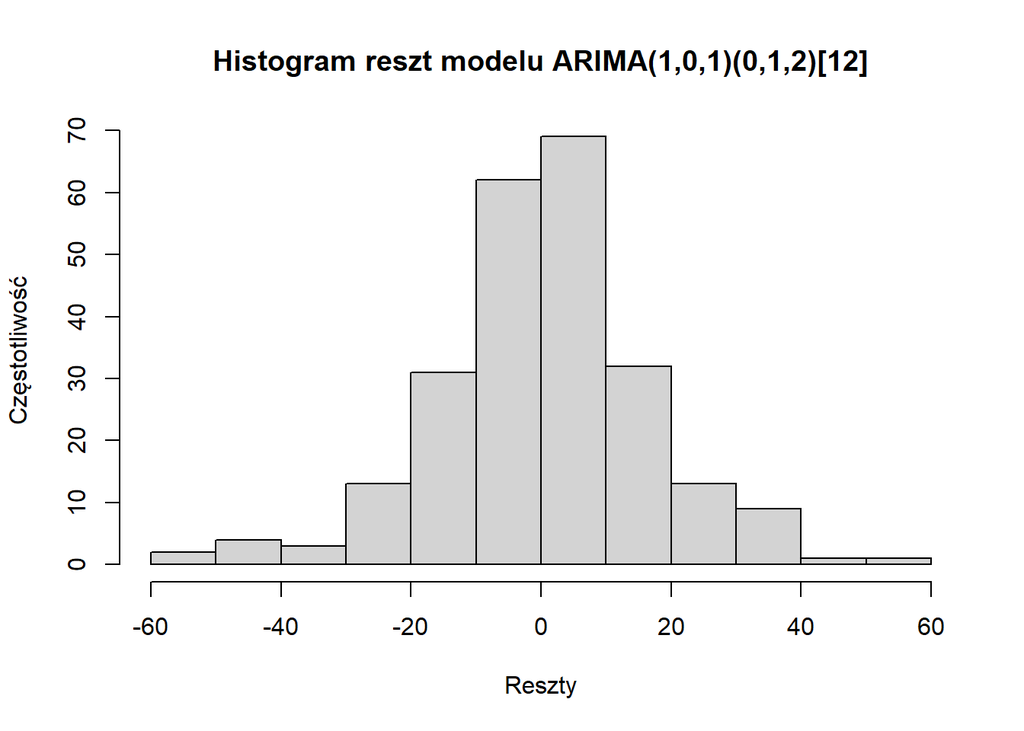

```r
hist(optymalny.arima.AIC.reszty,ylab="Częstotliwość", xlab="Reszty",main="Histogram reszt modelu ARIMA(1,0,1)(0,1,2)[12]")
```

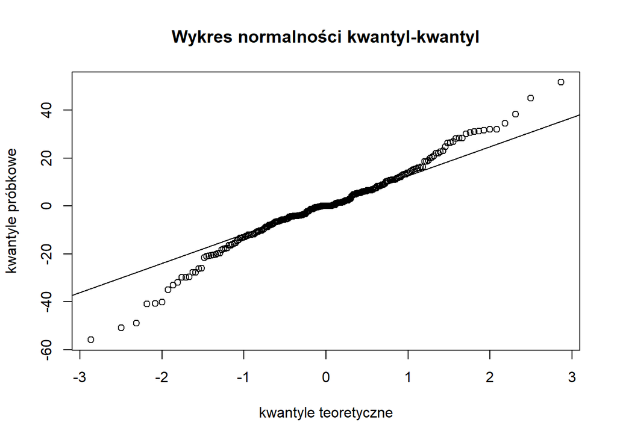

```r
qqnorm(optymalny.arima.AIC.reszty, main="Wykres normalności kwantyl-kwantyl", ylab="kwantyle próbkowe",xlab="kwantyle teoretyczne")
qqline(optymalny.arima.AIC.reszty)
```

Na podstawie pierwszego z nich można wysunąć przypuszczenie, iż reszty posiadają rozkład zbliżony do normalnego. Jednak patrząc na wykres kwantyl-kwantyl można zauważyć, że część wartości empirycznych nie pokrywa się z wartościami teoretycznymi, co może dementować to przypuszczenie - punkty na krańcach wykresu odstają od linii (model nie uwzględnia skrajnych wartości lub istnieją czynniki wpływające na rozkład danych, których model nie uwzględnia).

W celu dokładniejszej weryfikacji hipotezy o normalności rozkładu reszt modelu ARIMA wykorzystano **test Shapiro-Wilka.**

```r
shapiro.test(optymalny.arima.AIC.reszty)
```

```
##
##  Shapiro-Wilk normality test
##
## data:  optymalny.arima.AIC.reszty
## W = 0.97732, p-value = 0.0006862
```

Wartość testowa W wynosi 0.97732. Wartości testowej W bliskie 1 wskazują na to, że rozkład danych jest zbliżony do rozkładu normalnego. Równocześnie p-value wynosi 0.0006862. Jest to wartość bardzo mała, co oznacza, że istnieje bardzo małe prawdopodobieństwo, że dane pochodzą z rozkładu normalnego. Na podstawie wyników testu Shapiro-Wilka można stwierdzić, że rozkład reszt modelu ARIMA nie jest zgodny z rozkładem normalnym (hipoteza zerowa zostaje odrzucona).

Mimo że założenie o normalności reszt jest istotne dla wielu statystycznych metod, modele ARIMA nie są w pełni oparte na tym założeniu. Zakładają one stacjonarność szeregów czasowych oraz niezależność i jednorodność reszt. Choć normalność jest preferowana, to jej brak niekoniecznie uniemożliwia zastosowanie modelu w celu prognozowania. Nawet jeśli reszty nie mają rozkładu normalnego, model ARIMA może wciąż dawać dokładne prognozy. Ocenia się skuteczność modelu na podstawie innych metryk, takich jak błąd średniokwadratowy (RMSE) czy średni błąd bezwzględny (MAE). Jeśli modele ARIMA dają dobre wyniki prognozowane, mimo odstępstwa od normalności reszt, mogą być nadal użyteczne w praktyce, szczególnie przy prognozowaniu krótkoterminowym. W związku z tym zdecydowano się na przeprowadzenie prognozowania na 24 okresy (24 miesiące) w oparciu o stworzony model.

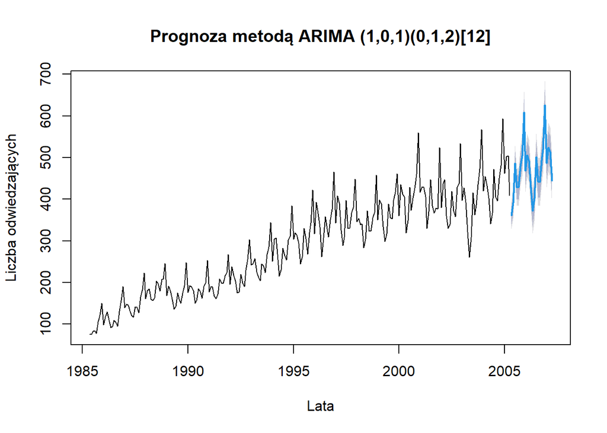

```r
ARIMA1.prognozy <- forecast(optymalny.arima.AIC, h=24)
plot(ARIMA1.prognozy, ylab="Liczba odwiedzających", xlab="Lata",main="Prognoza metodą ARIMA (1,0,1)(0,1,2)[12]")
```

Prognoza przy użyciu metody ARIMA (1,0,1)(0,1,2)[12] jednoznacznie wskazuje na tendencję wzrostową liczby odwiedzających Australię w kolejnych dwóch latach. Wykorzystując dane historyczne oraz analizę wzorców i trendów, model ARIMA przewiduje, że liczba odwiedzających będzie rosła w przyszłości.

### 6. Ocena jakości prognozy

Po dokonaniu analizy, kluczowym elementem jest ocena jakości analizy. W tym kontekście wykorzystano parametry takie jak AIC, AICc i BIC, oraz błędy ex post.

**Parametry AIC, AICc i BIC** są używane do porównywania różnych modeli statystycznych. Niższe wartości tych parametrów wskazują na lepsze dopasowanie modelu do danych, uwzględniając zarówno precyzję prognozowania, jak i złożoność modelu.

Oprócz parametrów informacyjnych, analiza jakości może obejmować również ocenę błędów ex post. Błędy ex post to różnice między rzeczywistymi wartościami a prognozowanymi wartościami. Przez analizę tych błędów można ocenić skuteczność modelu w prognozowaniu i zrozumieć, jak dobrze model radzi sobie z danymi. W tym przypadku wykorzystano błędy takie jak:

- **MAPE** mierzy procentowe średnie bezwzględne odchylenie między prognozowanymi wartościami a rzeczywistymi wartościami. Wykorzystuje się go do mierzenia błędu prognozy w stosunku do rzeczywistej wartości i jest przydatny w porównywaniu różnych modeli.
- **MAE** oblicza średnią bezwzględną różnicę między prognozowanymi a rzeczywistymi wartościami. Mierzy on bezwzględną wielkość błędu prognozy.
- **RMSE** oblicza pierwiastek średniego kwadratowego błędu między prognozowanymi a rzeczywistymi wartościami. Jest to popularna miara, która bierze pod uwagę zarówno wielkość, jak i kierunek błędu.

#### **6.1 Metody wygładzania wykładniczego**

```r
summary(visitors.ets.auto.prognoza)
```

```
##
## Forecast method: ETS(M,A,M)
##
## Model Information:
## ETS(M,A,M)
##
## Call:
##  ets(y = visitors, opt.crit = "mse", ic = "aicc")
##
##   Smoothing parameters:
##     alpha = 0.5653
##     beta  = 0.0215
##     gamma = 5e-04
##
##   Initial states:
##     l = 91.7613
##     b = 2.4333
##     s = 0.935 1.0545 1.0841 0.9724 1.3037 1.0824
##            1.0258 0.9102 0.9304 1.0521 0.8518 0.7976
##
##   sigma:  0.0565
##
##      AIC     AICc      BIC
## 2628.219 2630.976 2687.390
##
## Error measures:
##                       ME    RMSE      MAE        MPE     MAPE      MASE
## Training set -0.09495709 14.6622 10.97229 -0.3070136 4.188878 0.4051965
##                    ACF1
## Training set 0.07998858
##
## Forecasts:
##          Point Forecast    Lo 80    Hi 80    Lo 95    Hi 95
## May 2005       363.6434 337.2901 389.9967 323.3395 403.9474
## Jun 2005       389.5974 356.8764 422.3184 339.5550 439.6399
## Jul 2005       482.7709 437.0247 528.5172 412.8081 552.7338
## Aug 2005       428.5001 383.4951 473.5050 359.6709 497.3293
## Sep 2005       420.4548 372.1236 468.7860 346.5386 494.3710
## Oct 2005       475.5963 416.3290 534.8636 384.9547 566.2379
## Nov 2005       503.4598 435.9471 570.9725 400.2080 606.7116
## Dec 2005       608.3779 521.1122 695.6436 474.9165 741.8393
## Jan 2006       455.1525 385.6597 524.6452 348.8725 561.4324
## Feb 2006       509.0590 426.6702 591.4478 383.0562 635.0618
## Mar 2006       496.8101 411.8771 581.7431 366.9162 626.7039
## Apr 2006       441.9586 362.3923 521.5249 320.2724 563.6448
## May 2006       378.2099 306.6932 449.7266 268.8345 487.5852
## Jun 2006       405.1516 324.8788 485.4244 282.3849 527.9183
## Jul 2006       501.9810 397.9885 605.9736 342.9382 661.0239
## Aug 2006       445.4943 349.1776 541.8110 298.1906 592.7980
## Sep 2006       437.0751 338.6243 535.5258 286.5076 587.6425
## Oct 2006       494.3345 378.5064 610.1626 317.1908 671.4783
## Nov 2006       523.2309 395.8806 650.5813 328.4653 717.9965
## Dec 2006       632.1913 472.5654 791.8172 388.0646 876.3180
## Jan 2007       472.9103 349.1848 596.6358 283.6884 662.1322
## Feb 2007       528.8557 385.6501 672.0612 309.8416 747.8697
## Mar 2007       516.0680 371.5831 660.5529 295.0974 737.0386
## Apr 2007       459.0351 326.2850 591.7853 256.0113 662.0590
```

**Interpretacja wartości AIC, AICc i BIC:**

- AIC (Akaike Information Criterion) wynosi 2628.219. Wartość ta sugeruje, że model ma dobrą równowagę między precyzją prognoz a złożonością.

- AICc (skorygowane AIC) wynosi 2630.976, a więc model ma dobrą jakość dopasowania, biorąc pod uwagę skorygowaną złożoność modelu.

- BIC (Bayesian Information Criterion) wynosi 2687.390 i wskazuje na akceptowalną jakość dopasowania modelu, biorąc pod uwagę restrykcyjną ocenę związanej z złożonością modelu

#### **6.2 ARIMA**

Dla analizy **ARIMA wartości AIC, AICc i BIC** są następujące:

- AIC (Akaike Information Criterion) wynosi 1945.66 i sugeruje, że wybrany model ma dobrą równowagę między precyzją prognoz a złożonością modelu.

- AICc (skorygowane AIC) wynosi 1946.04, a więc wybrany model ma dobrą jakość dopasowania, biorąc pod uwagę skorygowaną złożoność modelu.

- BIC (Bayesian Information Criterion) wynosi 1966.2 i sugeruje, że wybrany model ma akceptowalną jakość dopasowania, biorąc pod uwagę restrykcyjną ocenę związanej z złożonością modelu.

### **7. Porównania wyników dla różnych zbiorów (szeregów) lub metod lub narzędzi**

W celu porównania dwóch metod analizy jednowymiarowego szeregu czasowego osób odwiedzających Australię w latach 1985-2005, tj. metody wygładzania wykładniczego i metody ARIMA, przeprowadzono analizę wartości AIC, AICc, BIC oraz błędów ex post.

**Metoda wygładzania wykładniczego** charakteryzuje się wartościami AIC równymi 2628.219, AICc wynoszącymi 2630.976 oraz BIC równymi 2687.390. Te wartości wskazują na dobre dopasowanie modelu, które uwzględnia zarówno precyzję prognoz, jak i złożoność modelu. Błędy ex post dla tej metody wynoszą średnio 10.97229 tys. osób dla MAE, 4.188878% dla MAPE oraz 14.6622 tys. osób dla RMSE.

Podsumowując, na podstawie wartości AIC, AICc, BIC oraz błędów ex post można stwierdzić, że metoda **ARIMA** może być lepszym wyborem do analizy jednowymiarowego szeregu czasowego osób odwiedzających Australię w latach 1985-2005.

### 8. Podsumowanie-wniosek

Na podstawie przeprowadzonej analizy, której celem było zidentyfikowanie sezonowości oraz trendu wśród osób odwiedzających Australię w latach 1985-2005, zaobserwowano wyraźny trend wzrostowy. Wykres prezentujący te dane ukazuje skierowaną w górę linię, co sugeruje systematyczny wzrost liczby odwiedzających w miarę upływu czasu.

W analizie zastosowano dwie metody: wygładzanie wykładnicze (metoda Holt-Wintersa) oraz ARIMA (AutoRegressive Integrated Moving Average), w celu prognozowania przyszłych wartości. Początkowo wybrany model wygładzania wykładniczego, oparty na metodzie Holt-Wintersa z modelem multiplikatywnym, okazał się trafny i uwzględniał zarówno sezonowość, jak i trend. Model ten uwzględniał wzrost liczby odwiedzających w sposób ciągły i dostarczał satysfakcjonujące wyniki prognoz.

Prognozy oparte na metodzie ARIMA wskazują, że trend wzrostowy liczby odwiedzających Australię będzie kontynuowany w przyszłości. Ta obserwacja może być wynikiem rozwoju turystyki zagranicznej w Australii, rosnącej popularności tego kraju jako celu podróży oraz korzyści związanych z promocją atrakcji turystycznych i dostępnością połączeń lotniczych.

Podsumowując, na podstawie przeprowadzonej analizy można stwierdzić, że metoda ARIMA jest bardziej odpowiednia do analizy danych z wyraźnym trendem wzrostowym, takim jak liczba odwiedzających Australię. Model ARIMA pozwala uwzględnić zarówno sezonowość, jak i skomplikowane wzorce występujące w danych, co przekłada się na bardziej precyzyjne prognozy. W konsekwencji, analiza jednowymiarowego szeregu czasowego osób odwiedzających Australię sugeruje, że trend wzrostowy będzie kontynuowany w przyszłości.

### 9. **Bibliografia**

A. Ganczarek-Gamrot, “Analiza szeregów czasowych”, Wydawnictwo Uniwersytetu Ekonomicznego w Katowicach, 2022

J. Nazarko, “Prognozowanie w zarządzaniu przedsiębiorstwem. Cz. IV. Prognozowanie na podstawie modeli trendu”, Politechnika Białostocka, 2017

A. Zagdański, A. Suchwałko “Analiza i prognozowanie szeregów czasowych”, PWN, 2015

[https://towardsdatascience.com](https://towardsdatascience.com/training-vs-testing-vs-validation-sets-a44bed52a0e1)

https://www.askpython.com/python/examples/split-data-training-and-testing-set

https://departmentofstatisticspue.github.io/statystyka-opisowa/sezonowo-.html